# Exam project

May 12, 2021

## Agenda

- Introduction
  - Sampling
  - Dataset - prior to cleaning
- Materials and methods
  - From raw data to results
- Results
  - Precision of taxonomic classification
  - Community composition
  - Alpha diversity
  - Beta diversity
- Discussion

## Introduction

- **Dataset:** OTU table
- **Source:** *Effects of industrial effluents containing moderate levels of antibiotic mixtures on the abundance of antibiotic resistance genes and bacterial community composition in exposed creek sediments*; Milakovic et.al, 2019 https://www.sciencedirect.com/science/article/pii/S0048969719359972
- **Sequencing method:** Illumina-based 16S amplicon sequencing
- **Sampling location:** Kalinivica creek, Croatia. By antibiotic production facility wastewater outlet
- **Our aim:** Evaluate effect of wastewater discharge from antibiotic factory on bacterial community composition

## Sampling

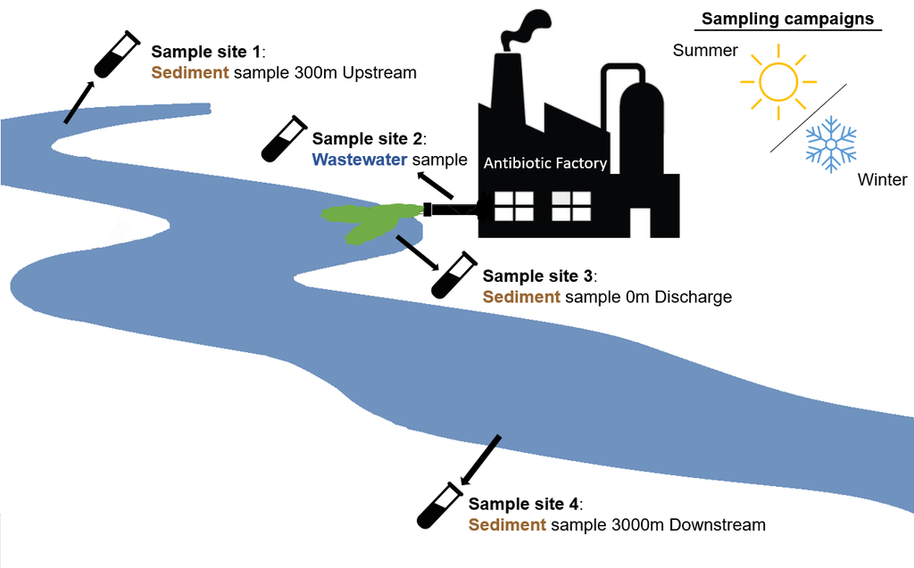

## Dataset - prior to cleaning

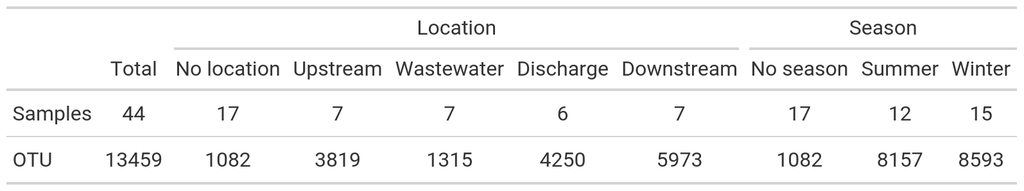

## Flowchart: From raw data to results

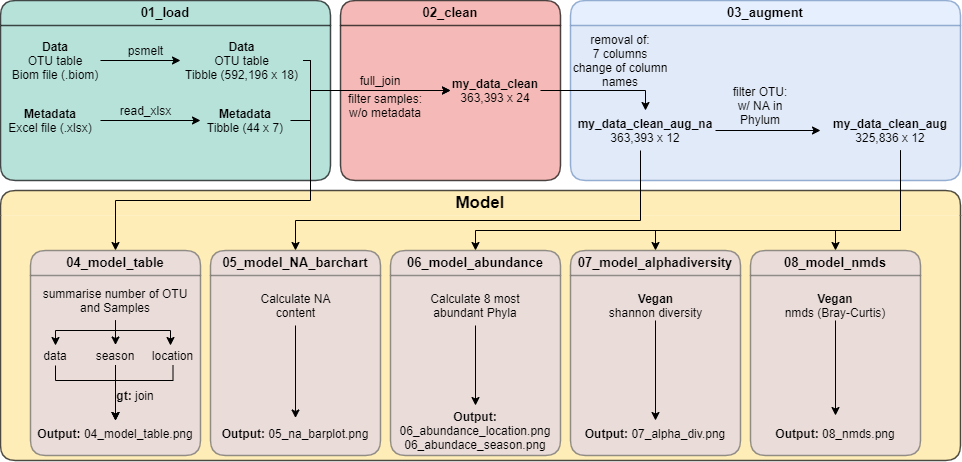

## Precision of taxonomic classification

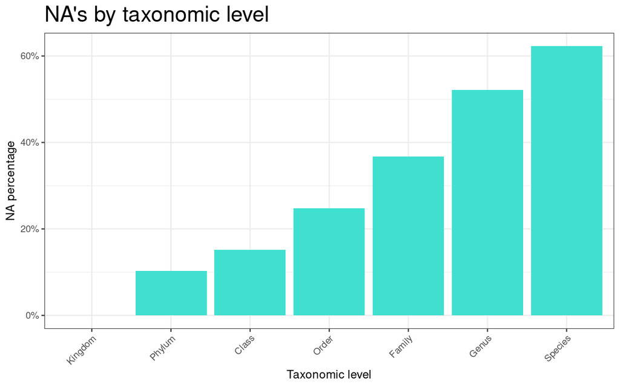

## Community composition by phyla

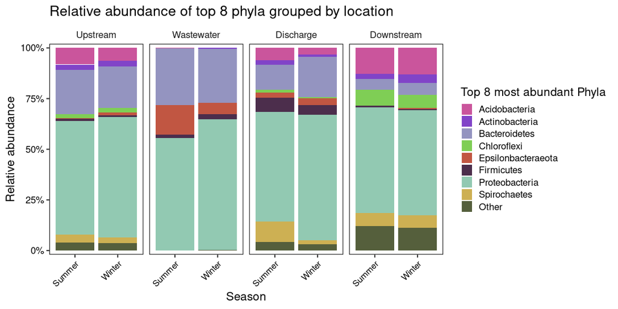

## Community composition by phyla

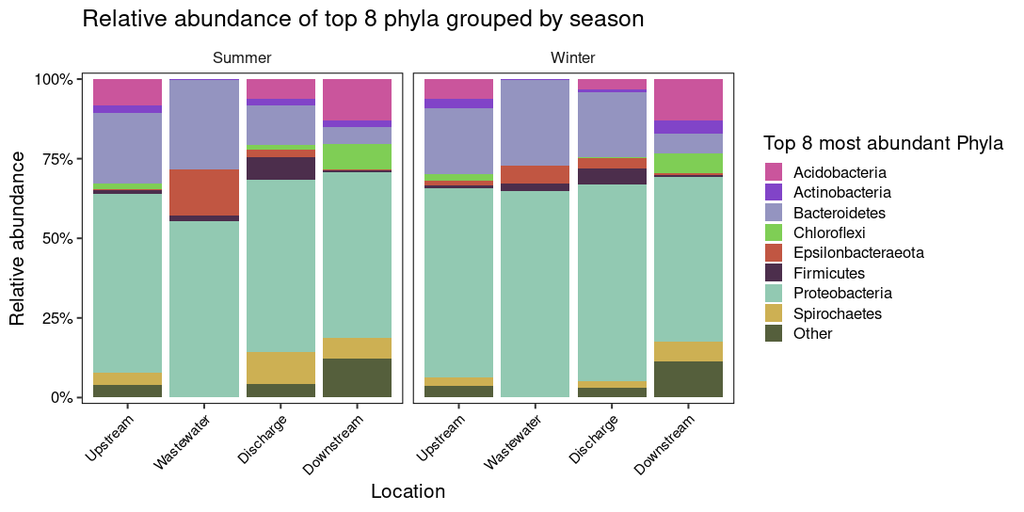

## Alpha diversity

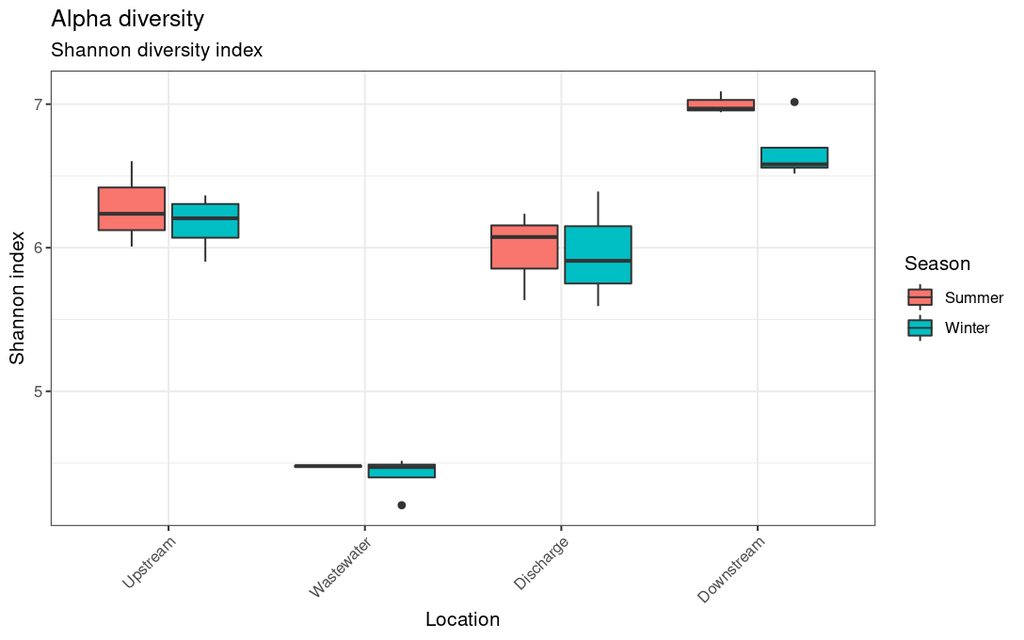

## Beta diversity

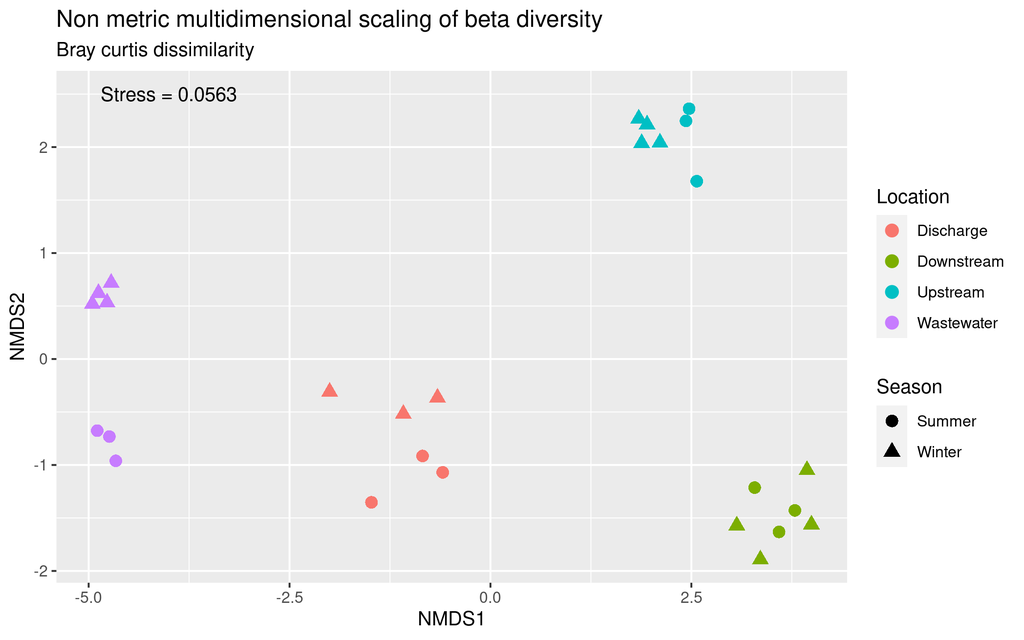

## Discussion - Wastewater samples

- **Wastewater samples are different from other samples both on diversity and composition**
  - Wastewater as an environmental sample differs in physical properties compared to sediment samples
  - Wastewater samples are more a snapshot, due to water flow
  - Could possibly exclude wastewater samples

## Discussion - Effects on community composition

- **Location has more impact on diversity and composition**
  - **NMDS:** mainly clustering based on location
  - **NMDS:** less clustering based on sampling season
- **Downstream communities are the most diverse**
  - Many species are able to survive the high concentrations of antibiotics
  - Literature suggests that selective pressure from antibiotics can increase diversity (*Bengtsson-Palme et al., 2019*)
  - Different environment downstream (forest) than upstream (agricultural)